# Economy Growing Backwards?

The Case of Reverse Structural Transformation in Uttar Pradesh

Author

Jyotiraditya Pradhan

As of 2025, Uttar Pradesh was among the states with the fastest growing economy in India, boasting a [growth rate of about 9.2%](https://prsindia.org/budgets/states/uttar-pradesh-budget-analysis-2026-27) in 2024-2025. The investments in the state have been soaring. This is partly indicated by the massive rise in its cumulative FDI inflow since the year 2000 - which stood at just about [Rs 3,000 crores in March 2017](https://www.dpiit.gov.in/static/uploads/2025/07/51f2612c2b22d32bbc01fcb3c1a8d0a9.pdf), but soared to over [Rs 22,000 crore in September 2025](https://www.dpiit.gov.in/static/uploads/2025/12/7b947761f3bb819d1092c7a189f37834.pdf).

But how have these achievements in growth translated to the kind of jobs people have? Data from the government’s own Periodic Labor Force Surveys (PLFS) give us some answers. But they also raise more questions about how the benefits of India’s growth story is delivered to its people.

## A Growing Workforce

|  | Labour Force Participation Rate (%) 2017 | Labour Force Participation Rate (%) 2023 | Labour Force Participation Rate (%) Change | Unemployment Rate (%) 2017 | Unemployment Rate (%) 2023 | Unemployment Rate (%) Change |
| --- | --- | --- | --- | --- | --- | --- |
| Overall |  |  |  |  |  |  |
| Uttar Pradesh | 42.7 | 52.1 | 9.4 | 8.4 | 4.3 | −4.1 |
| India | 47.6 | 56.0 | 8.4 | 7.3 | 4.2 | −3.1 |
| Gender |  |  |  |  |  |  |
| Female, Uttar Pradesh | 11.3 | 27.2 | 15.9 | 4.8 | 3.3 | −1.4 |
| Female, India | 20.7 | 35.3 | 14.6 | 7.4 | 4.3 | −3.2 |
| Male, Uttar Pradesh | 73.4 | 77.3 | 3.8 | 9.0 | 4.7 | −4.3 |
| Male, India | 74.0 | 77.0 | 3.0 | 7.3 | 4.2 | −3.1 |
| Caste |  |  |  |  |  |  |
| SC, Uttar Pradesh | 43.5 | 53.8 | 10.3 | 9.7 | 4.4 | −5.3 |
| SC, India | 49.1 | 57.0 | 8.0 | 8.6 | 4.7 | −3.9 |
| ST, Uttar Pradesh | 42.6 | 52.9 | 10.3 | 6.5 | 0.7 | −5.8 |
| ST, India | 54.3 | 66.1 | 11.8 | 5.9 | 3.1 | −2.7 |
| OBC, Uttar Pradesh | 43.2 | 53.1 | 9.9 | 7.9 | 4.0 | −3.9 |
| OBC, India | 47.2 | 55.6 | 8.4 | 7.1 | 4.1 | −3.0 |
| Other, Uttar Pradesh | 40.6 | 47.2 | 6.6 | 8.4 | 5.5 | −3.0 |
| Other, India | 45.2 | 52.4 | 7.2 | 7.2 | 4.5 | −2.7 |

Table 1: Labour Force Participation & Unemployment Rates across different categories in Uttar Pradesh & India

Table 1 above shows two common statistics used to gauge the state of labour market of an economy. The *labour force participation rate* (LFPR) shows share of working age population (i.e. age over 15 years) that is either employed or actively searching for a job. This part of the population is known as the labour force. The *unemployment rate* shows the share of the labour force that is not able to find employment.

The fall of unemployment rate is also consistent across categories, with UP performing better than the Indian average. Even in the case of unemployment rates among females, where the drop has been lower in UP, it must be noted that UP already had very low levels of female unemployment in 2017.

These statistics paint a rosy picture of the labour market in the state. But digging deeper shows some unexpected changes.

## Shift in Sectors

As an economy grows, the kind of jobs available are expected to shift from low productivity sectors like agriculture to higher productivity ones like manufacturing & services. This process is known as *structural transformation*.

Figure 1 below depicts a boxplot. The thick vertical line in the middle of each box shows the median monthly income of a person working in that sector (i.e. the income of the person who would be in the middle if everyone was ranked by their income). The width of the boxes and whiskers (thin lines on both sides), show the spread of the data.

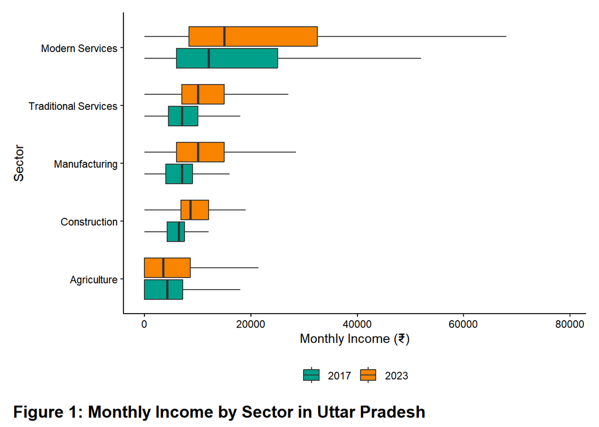

A good proxy of the level of productivity of a sector are the incomes of people employed in it. The ranking shown above is as expected: Modern services pay the highest at median, with also a significant spread of higher earnings. This is followed by traditional services, manufacturing & construction. And finally, agriculture pays the lowest. This hierarchy is consistent across both years. One point to note is that median agricultural incomes have dropped between 2017 & 2023, contrary to every other sector.

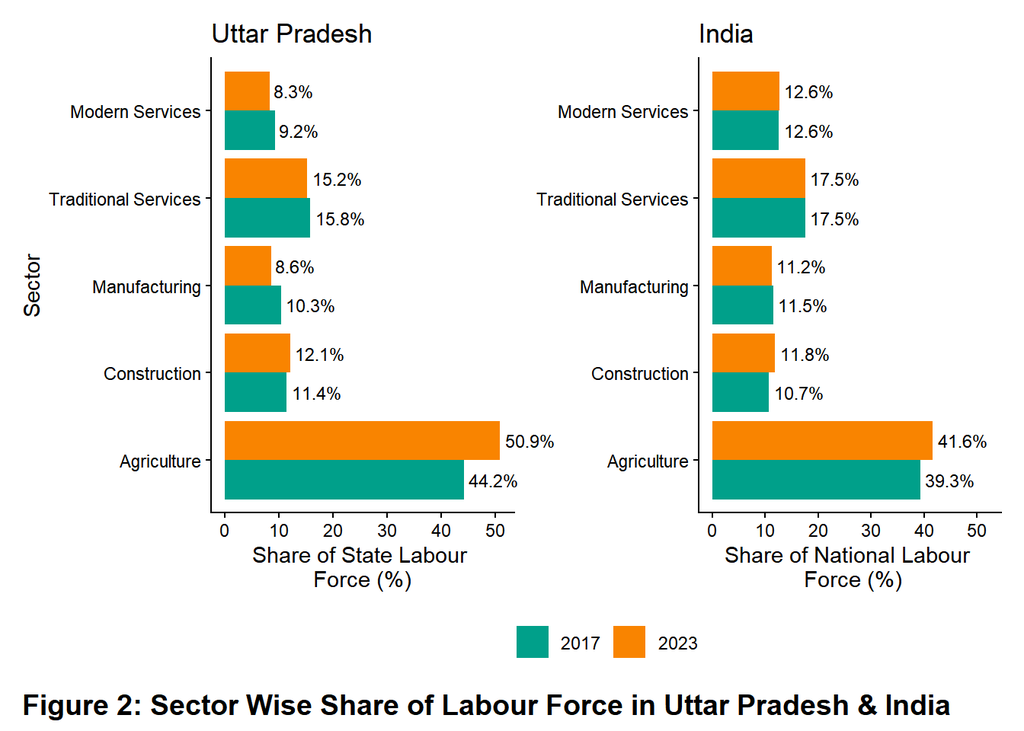

Running counter to the path expected of a growing economy, Figure 2 shows the share of labour force increasing significantly in agriculture and slightly in construction - the sectors with the lowest productivity. The increase in agriculture is significantly higher compared to the national average, and paired with the observation of falling income in agriculture in Figure 1, this makes the picture bleaker. Moreover, in UP, the share of labour force employed in remaining three higher productivity sectors have fallen. This process has come to be called by economists as *reverse structural transformation* or *structural retrogression*.

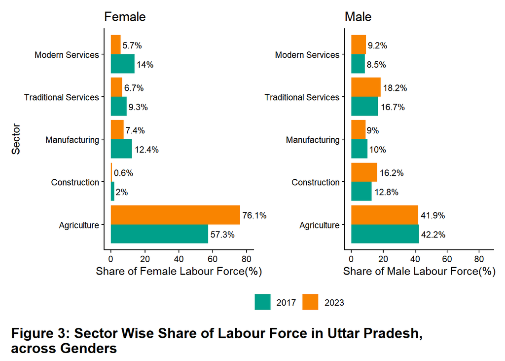

Figure 3 depicts a sharp difference of *reverse structural transformation* between genders in UP. In fact, almost all of the shift towards lower productivity sector comes from females. Females were already concentrated in Agriculture to a much greater extent in 2017. However, by 2023 there is a massive spike in this concentration. The shares of males across sectors has been relatively unchanged.

Figure 4 shows that reverse structural transformation has been the sharpest for STs, with a stark rise in agriculture and fall in services. This is followed by SCs & OBCs, with similar but smaller shifts. For Other castes, there is slight rise in agriculture paired with fall in construction and manufacturing. However, they have also seen a rise in both traditional and modern services.

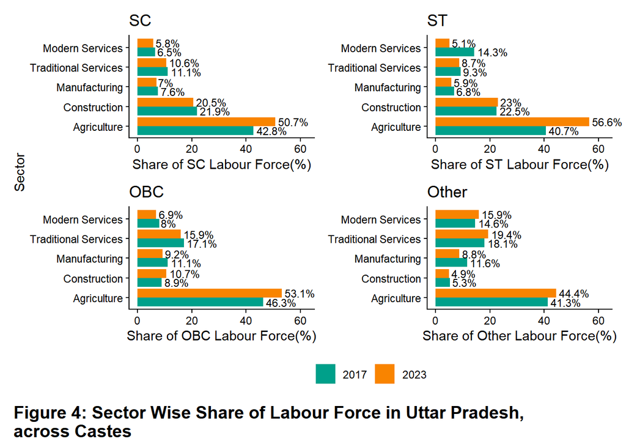

The above two figures show that *reverse structural transformation* in UP has been occurring for mainly for females and marginalized castes.

## Shift in Employment Types

Similar to the shift towards productive sectors, the labour force in a growing economy is expected to also towards regular salaried work.

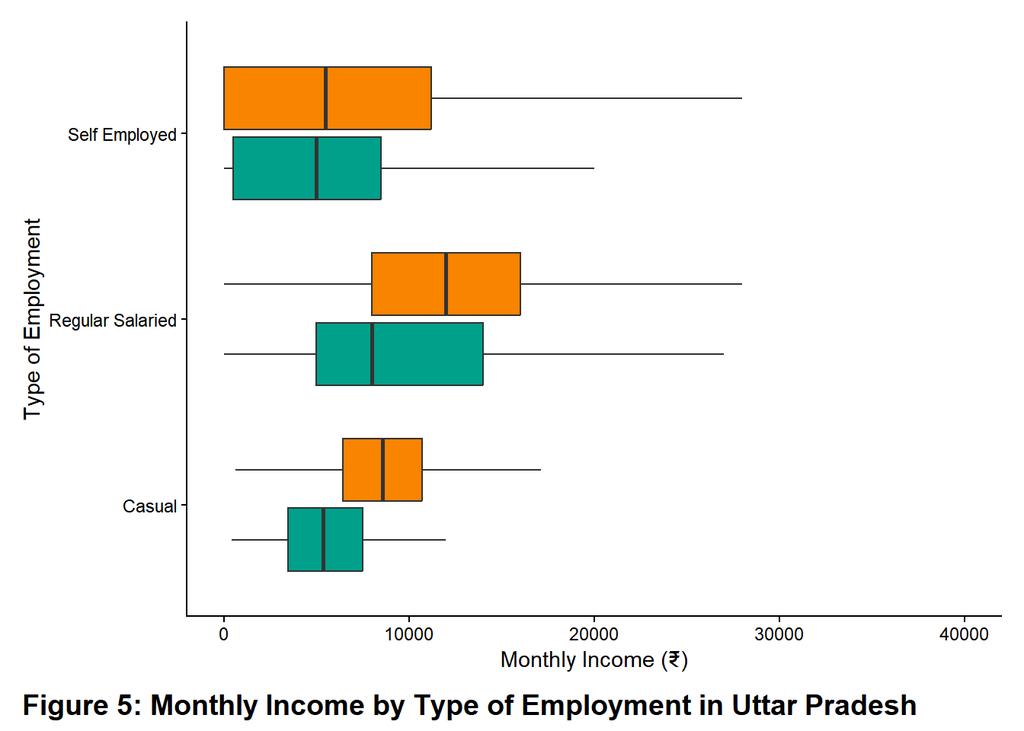

Figure 5 shows that regular salaried workers earn the most at median in the state in both the years. This is followed by casual workers. Self employed workers earn the least, as this category involves a large number of own account workers, small business owners, and unpaid family helpers.

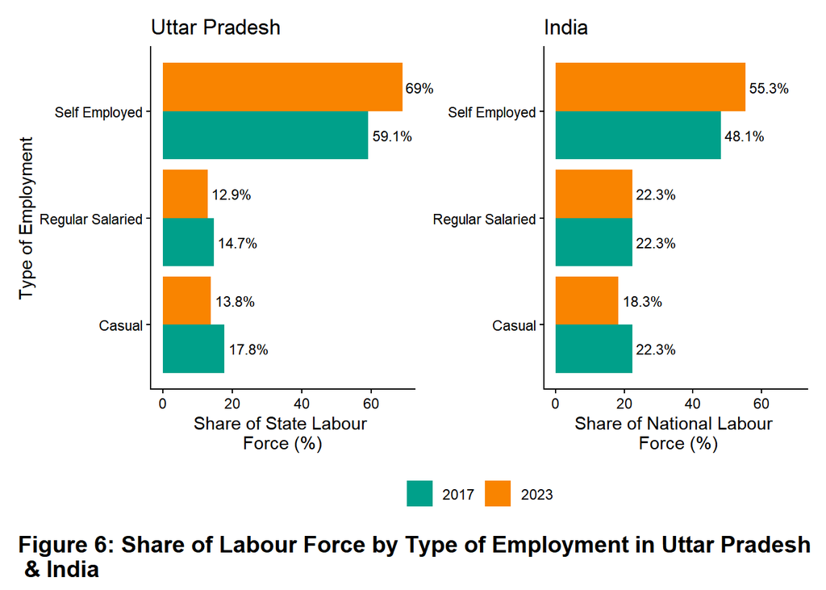

Figure 6 shows that there has been a drop in the share of regular salaried employees as well as the casual workers in the UP. This is paired with a significant rise in share of self employed. Similar to the Figure 2, the shift is more pronounced in UP compared to the Indian aggregate.

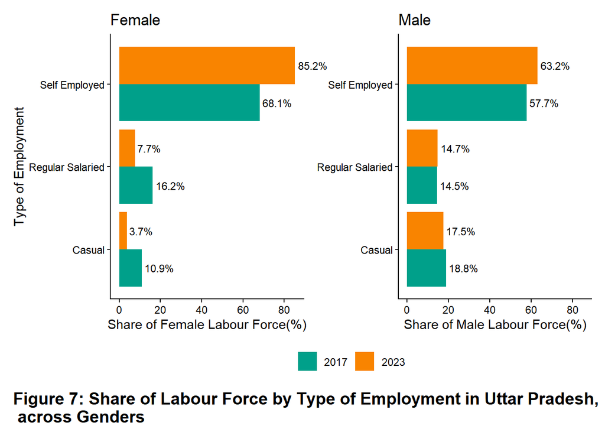

In Figure 7, similar as before, almost all of the reverse structural transformation in the state is coming from females. Only females show a significant drop in the share of regular salaried and casual workers. The increase in share of self employed workers is seen in both genders, but is much greater for females.

Figure 8 also shows patterns similar to Figure 4. The share of regular salaried workers is prominently seen only among STs. The share of casual employees has increased in ST, in contrast to others. The increase in share of self employed workers is similar for SCs and STs, followed by OBC and Other castes.

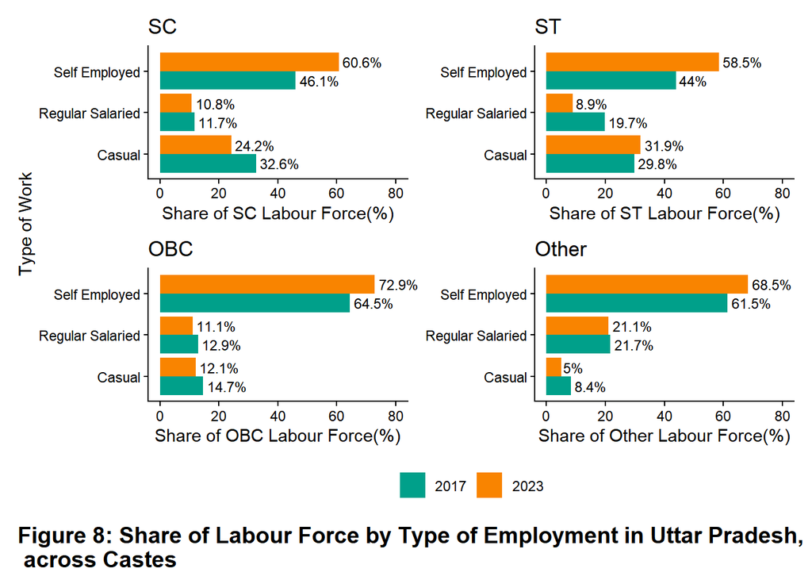

Similar to the shift in sectors, the above two figures also show that *reverse structural transformation* occurs disproportionately for females & backward classes in UP.

## Whose Growth?

> “Whatever you can rightly say about India, the opposite is also true.  
> — Joan Robinson

The dichotomy of rapid growth being coupled with undesirable labour market outcomes is not a new phenomena in India. This has previously take the form of *jobless growth*, when growth did not translate into sufficient jobs being created. However, we seem to have entered a new phase where jobs are being created, but largely being low productive ones - as shown in the case of Uttar Pradesh here.

The dynamics of *reverse structural transformation* raises several questions about the distributional aspects of our economic growth: How is growth befitting different people if it is not translating into better jobs for some? How excluded are women and marginalized communities? What will be the long run impact of this on India’s growing inequality?

This is a pressing issue that warrants further scrutiny in our public discourse.